# Final Project 320 - NBA

Justin De Burgo, Sherief El-Ghazawi, Josue Arana

5/18/2020

Things to consider

## Motivation

Does the tutorial make the reader believe the topic is relevant or important (i) in general and (ii) with respect to data science?

## Understanding.

After reading through the tutorial, does an uninformed reader feel informed about the topic? Would a reader who already knew about the topic feel like s/he learned more about it?

## Other resources.

Does the tutorial link out to other resources (on the web, in books, etc) that would give a lagging reader additional help on specific topics, or an advanced reader the ability to dive more deeply into a specific application area or technique?

## Prose.

Does the prose portion of the tutorial actually add to the content of the deliverable?

## Code.

Is the code well written, well documented, reproducible, and does it help the reader understand the tutorial? Does it give good examples of specific techniques?

## Subjective evaluation.

If somebody linked to this tutorial from, say, Hacker News, would people actually read through the entire thing? Group Work

## Data Collection

First let’s import the packages and libraries we’ll need.

```r
library(tidyverse)
```

```r
library(ggplot2)
```

We’ll read the CSV and turn it into an R DataFrame for further analysis.

```r
nba_seasons <- read_csv("NBA_Season_Data.csv")
nba_seasons1 <- nba_seasons%>%
                filter(Year >= 2000)
nba_seasons1
```

```
## # A tibble: 9,048 x 109
##     Year Tm    Player   Age     G    MP   PER `TS%` `3PAr`   FTr `ORB%` `DRB%`
##    <dbl> <chr> <chr>  <dbl> <dbl> <dbl> <dbl> <dbl>  <dbl> <dbl>  <dbl>  <dbl>
##  1  2000 DAL   Micha…    26    82  3464  19.2 0.522  0.151 0.194    3.8   12.2
##  2  2000 SEA   Gary …    31    82  3425  23.6 0.535  0.312 0.254    3.2   13.9
##  3  2000 NYK   Latre…    29    82  3276  15.7 0.515  0.097 0.304    1.8   10.5
##  4  2000 MIN   Kevin…    23    81  3243  23.6 0.545  0.053 0.265    7.9   26.6
##  5  2000 VAN   Share…    23    82  3223  20.2 0.547  0.075 0.431    8     22.7
##  6  2000 NYK   Allan…    28    82  3169  16.5 0.569  0.191 0.263    1.5    8.5
##  7  2000 LAL   Shaqu…    27    79  3163  30.6 0.578  0.001 0.495   11.5   24.8
##  8  2000 VAN   Mike …    21    82  3155  16.7 0.521  0.206 0.242    2.8    8.9
##  9  2000 DET   Jerry…    25    82  3148  18.9 0.545  0.199 0.524    4.3    7.2
## 10  2000 CHH   Antho…    33    82  3133  14.4 0.56   0.002 0.637    5.3   19.4
## # … with 9,038 more rows, and 97 more variables: `TRB%` <dbl>, `AST%` <dbl>,
## #   `STL%` <dbl>, `BLK%` <dbl>, `TOV%` <dbl>, `USG%` <dbl>, . <lgl>, OWS <dbl>,
## #   DWS <dbl>, WS <dbl>, `WS/48` <dbl>, ._1 <lgl>, OBPM <dbl>, DBPM <dbl>,
## #   BPM <dbl>, VORP <dbl>, `OWS/48` <dbl>, `DWS/48` <dbl>, `Shot%` <dbl>,
## #   `Player ID` <chr>, `Team Mar` <dbl>, `Team MP` <dbl>, `Team Gm` <dbl>,
## #   `Year 3PAr` <dbl>, `Team TS%` <dbl>, `Tm USG` <dbl>, `Tm TS W/O
## #   Plyr` <dbl>, `Reb/Vers` <dbl>, Defense <dbl>, `Val/Shot` <dbl>,
## #   Offense <dbl>, `MPG + Int` <dbl>, `RAW SPM` <dbl>, `%Min` <chr>, `RAW
## #   Contrib` <dbl>, `Tm Sum` <dbl>, `Tm Adj` <dbl>, BPM_1 <dbl>, StdErr <dbl>,
## #   Contrib <dbl>, VORP_1 <dbl>, `Reb/Vers_1` <dbl>, `Val/Shot_1` <dbl>,
## #   Offense_1 <dbl>, Defense_1 <dbl>, MPG <dbl>, `Raw OBPM` <dbl>,
## #   Contrib_1 <dbl>, `Tm Ortg` <dbl>, `Tm Sum_1` <dbl>, `Tm Adj_1` <dbl>, `Tm
## #   DRtg` <dbl>, OBPM_1 <dbl>, OStdErr <dbl>, Ocontrib <dbl>, OVORP <dbl>,
## #   DBPM_1 <dbl>, DStdErr <dbl>, Dcontrib <dbl>, DVORP <dbl>, `Sum SPM` <dbl>,
## #   `%Min_1` <dbl>, MPG_1 <dbl>, ReMPG <dbl>, BPM_2 <dbl>, Contrib_2 <dbl>,
## #   VORP_2 <dbl>, `VORP-Gm` <dbl>, `O-BPM` <dbl>, Ocontrib_1 <dbl>,
## #   OVORP_1 <dbl>, `OVORP-Gm` <dbl>, `D-BPM` <dbl>, Dcontrib_1 <dbl>,
## #   DVORP_1 <dbl>, `DVORP-Gm` <dbl>, Production <chr>, `Prod-Gm` <chr>, `Exp
## #   BPM` <dbl>, TrueTalentBPM <dbl>, `Exp%Min` <dbl>, TrueTalentVORP <dbl>,
## #   TrueSalary <chr>, TrueTimeVORP <dbl>, `Adjusted Production` <chr>,
## #   WORP <dbl>, `O-WORP` <dbl>, `D-WORP` <dbl>, `Adjusted WORP` <dbl>,
## #   `Estimated Position` <dbl>, `BBRef Pos` <dbl>, `Age on Feb 1` <dbl>, `Yrs
## #   Experience` <dbl>, Height <dbl>, Weight <dbl>, `Rounded Position` <dbl>,
## #   `Rounded Age` <dbl>
```

```r
distinct(nba_seasons1, Tm)
```

```
## # A tibble: 37 x 1
##    Tm
##    <chr>
##  1 DAL
##  2 SEA
##  3 NYK
##  4 MIN
##  5 VAN
##  6 LAL
##  7 DET
##  8 CHH
##  9 TOR
## 10 MIL
## # … with 27 more rows
```

```r
nba_finals_mvp <- read_csv("NBA_Finals_and_MVP.csv")
```

```r
nba_finals_mvp <- nba_finals_mvp%>%
                filter(Year >= 2000)
for (row in 1:nrow(nba_finals_mvp)) {

 if (nba_finals_mvp[row, "NBA Champion"] == "Los Angeles Lakers") {
   nba_finals_mvp[row, "NBA Champion"] <- "LAL"
 }

  if (nba_finals_mvp[row, "NBA Champion"] == "Golden State Warriors") {
   nba_finals_mvp[row, "NBA Champion"] <- "GSW"
  }

  if ( nba_finals_mvp[row, "NBA Champion"] == "Cleveland Cavaliers") {
   nba_finals_mvp[row, "NBA Champion"] <- "CLE"
  }

  if (nba_finals_mvp[row, "NBA Champion"] == "San Antonio Spurs") {
   nba_finals_mvp[row, "NBA Champion"] <- "SAS"
  }


  if ( nba_finals_mvp[row, "NBA Champion"] == "Miami Heat") {
   nba_finals_mvp[row, "NBA Champion"] <- "MIA"
  }

  if (nba_finals_mvp[row, "NBA Champion"] == "Dallas Mavericks") {
   nba_finals_mvp[row, "NBA Champion"] <- "DAL"
  }

  if (nba_finals_mvp[row, "NBA Champion"] == "Boston Celtics") {
   nba_finals_mvp[row, "NBA Champion"] <- "BOS"
  }

  if (nba_finals_mvp[row, "NBA Champion"] == "Detroit Pistons") {
   nba_finals_mvp[row, "NBA Champion"] <- "DET"
  }

}
```

```r
nba_performance <- read_csv("Historical_NBA_Performance.csv")
nba_performance <- nba_performance%>%
                filter(Year >= 2000)
for (row in 1:nrow(nba_performance)) {

  if (nba_performance[row, "Team"] == "Nets") {
   nba_performance[row, "Team"] <- "BRK"
 }

  if (nba_performance[row, "Team"] == "Thunder") {
   nba_performance[row, "Team"] <- "OKC"
 }

  if (nba_performance[row, "Team"] == "Pelicans") {
   nba_performance[row, "Team"] <- "NOP"
 }

  if (nba_performance[row, "Team"] == "Grizzlies") {
   nba_performance[row, "Team"] <- "MEM"
 }

  if (nba_performance[row, "Team"] == "Magic") {
   nba_performance[row, "Team"] <- "ORL"
 }

  if (nba_performance[row, "Team"] == "Clippers") {
   nba_performance[row, "Team"] <- "LAC"
 }

  if (nba_performance[row, "Team"] == "Rockets") {
   nba_performance[row, "Team"] <- "HOU"
 }

  if (nba_performance[row, "Team"] == "Suns") {
   nba_performance[row, "Team"] <- "PHO"
 }

  if (nba_performance[row, "Team"] == "Trail Blazers") {
   nba_performance[row, "Team"] <- "POR"
 }

  if (nba_performance[row, "Team"] == "76ers") {
   nba_performance[row, "Team"] <- "PHI"
 }

  if (nba_performance[row, "Team"] == "Kings") {
   nba_performance[row, "Team"] <- "SAC"
 }


  if (nba_performance[row, "Team"] == "Wizards") {
   nba_performance[row, "Team"] <- "WAS"
 }

  if (nba_performance[row, "Team"] == "Jazz") {
   nba_performance[row, "Team"] <- "UTA"
 }

  if (nba_performance[row, "Team"] == "Nuggets") {
   nba_performance[row, "Team"] <- "DEN"
 }

  if (nba_performance[row, "Team"] == "Hawks") {
   nba_performance[row, "Team"] <- "ATL"
  }

  if (nba_performance[row, "Team"] == "Pacers") {
   nba_performance[row, "Team"] <- "IND"
 }

  if (nba_performance[row, "Team"] == "Bulls") {
   nba_performance[row, "Team"] <- "CHI"
 }

  if (nba_performance[row, "Team"] == "Hornets" || nba_performance[row, "Team"] == "Bobcats") {
   nba_performance[row, "Team"] <- "CHH"
 }

  if (nba_performance[row, "Team"] == "Bucks") {
   nba_performance[row, "Team"] <- "MIL"
 }

  if (nba_performance[row, "Team"] == "Raptors") {
   nba_performance[row, "Team"] <- "TOR"
 }

  if (nba_performance[row, "Team"] == "Timberwolves") {
   nba_performance[row, "Team"] <- "MIN"
 }

  if (nba_performance[row, "Team"] == "Knicks") {
   nba_performance[row, "Team"] <- "NYK"
 }

   if (nba_performance[row, "Team"] == "Supersonics") {
   nba_performance[row, "Team"] <- "SEA"
 }

 if (nba_performance[row, "Team"] == "Lakers") {
   nba_performance[row, "Team"] <- "LAL"
 }

  if (nba_performance[row, "Team"] == "Warriors") {
   nba_performance[row, "Team"] <- "GSW"
  }

  if ( nba_performance[row, "Team"] == "Cavaliers") {
   nba_performance[row, "Team"] <- "CLE"
  }

  if (nba_performance[row, "Team"] == "Spurs") {
   nba_performance[row, "Team"] <- "SAS"
  }


  if ( nba_performance[row, "Team"] == "Heat") {
   nba_performance[row, "Team"] <- "MIA"
  }

  if (nba_performance[row, "Team"] == "Mavericks") {
   nba_performance[row, "Team"] <- "DAL"
  }

  if (nba_performance[row, "Team"] == "Celtics") {
   nba_performance[row, "Team"] <- "BOS"
  }

  if (nba_performance[row, "Team"] == "Pistons") {
   nba_performance[row, "Team"] <- "DET"
  }

}
distinct(nba_performance, Team)
```

```
## # A tibble: 31 x 1
##    Team
##    <chr>
##  1 BOS
##  2 ATL
##  3 BRK
##  4 CHH
##  5 CHI
##  6 CLE
##  7 DAL
##  8 DEN
##  9 DET
## 10 GSW
## # … with 21 more rows
```

```r
nba_performance
```

```
## # A tibble: 506 x 10
##    Year     Team  Record `Winning Percentag… X5    X6    X7    X8    X9    X10
##    <chr>    <chr> <chr>                <dbl> <lgl> <lgl> <lgl> <lgl> <lgl> <chr>
##  1 2016-17  BOS   25-15                0.625 NA    NA    NA    NA    NA    <NA>
##  2 2015-16  BOS   48-34                0.585 NA    NA    NA    NA    NA    <NA>
##  3 2014-15  BOS   40-42                0.488 NA    NA    NA    NA    NA    <NA>
##  4 2013-14  BOS   25-57                0.305 NA    NA    NA    NA    NA    <NA>
##  5 2012-13  BOS   41-40                0.506 NA    NA    NA    NA    NA    <NA>
##  6 2011-12… BOS   39-27                0.591 NA    NA    NA    NA    NA    <NA>
##  7 2010-11  BOS   56-26                0.683 NA    NA    NA    NA    NA    <NA>
##  8 2009-10  BOS   50-32                0.61  NA    NA    NA    NA    NA    <NA>
##  9 2008-09  BOS   62-20                0.756 NA    NA    NA    NA    NA    <NA>
## 10 2007-08  BOS   66-16                0.805 NA    NA    NA    NA    NA    <NA>
## # … with 496 more rows
```

```r
nba_champs <- select(nba_finals_mvp, 1, 5) %>%
                filter(Year >= 2000) %>%
                arrange(desc(Year))
nba_champs
```

```
## # A tibble: 19 x 2
##     Year `NBA Champion`
##    <dbl> <chr>
##  1  2018 GSW
##  2  2017 GSW
##  3  2016 CLE
##  4  2015 GSW
##  5  2014 SAS
##  6  2013 MIA
##  7  2012 MIA
##  8  2011 DAL
##  9  2010 LAL
## 10  2009 LAL
## 11  2008 BOS
## 12  2007 SAS
## 13  2006 MIA
## 14  2005 SAS
## 15  2004 DET
## 16  2003 SAS
## 17  2002 LAL
## 18  2001 LAL
## 19  2000 LAL
```

```r
nba_seasons_offense <- select(nba_seasons1, Year, Tm, Player, Offense=Offense_1, Defense = Defense_1)
nba_seasons_offense
```

```
## # A tibble: 9,048 x 5
##     Year Tm    Player              Offense Defense
##    <dbl> <chr> <chr>                 <dbl>   <dbl>
##  1  2000 DAL   Michael Finley          1.3     0
##  2  2000 SEA   Gary Payton             4.7     0.3
##  3  2000 NYK   Latrell Sprewell       -0.3     0.1
##  4  2000 MIN   Kevin Garnett           1       0
##  5  2000 VAN   Shareef Abdur-Rahim     0.4    -0.1
##  6  2000 NYK   Allan Houston           2.2    -0.1
##  7  2000 LAL   Shaquille O'Neal        3.9    -0.6
##  8  2000 VAN   Mike Bibby              0.1     0.2
##  9  2000 DET   Jerry Stackhouse        0.5     0
## 10  2000 CHH   Anthony Mason          -0.6    -0.1
## # … with 9,038 more rows
```

```r
nba_seasons_offense %>%
  arrange(desc(Offense)) %>%
  slice(1:100)
```

```
## # A tibble: 100 x 5
##     Year Tm    Player          Offense Defense
##    <dbl> <chr> <chr>             <dbl>   <dbl>
##  1  2014 MIA   DeAndre Liggins    29.1    -0.5
##  2  2005 NYK   Jackie Butler      24.4     3.2
##  3  2008 HOU   Gerald Green       23.8    -0.5
##  4  2016 LAL   Anthony Brown      23.5    -0.5
##  5  2009 SAS   Marcus Williams    21.5    -0.5
##  6  2004 TOR   Chris Jefferies    16.1    -0.5
##  7  2009 OKC   Steven Hill        15.3    -0.5
##  8  2016 TOR   Lucas Nogueira     15.3     5.3
##  9  2000 ORL   Earl Boykins       14.4    -0.5
## 10  2015 SAC   Eric Moreland      14.4    -0.5
## # … with 90 more rows
```

```r
offense <- nba_seasons_offense %>%
              filter(Year >= 2000) %>%
              group_by(Year, Tm) %>%
              summarize(mean_offense=sum(Offense), mean_defense=sum(Defense))
offense <- offense %>%
            arrange(desc(mean_offense))
offense
```

```
## # A tibble: 505 x 4
## # Groups:   Year [17]
##     Year Tm    mean_offense mean_defense
##    <dbl> <chr>        <dbl>        <dbl>
##  1  2014 MIA          21          -0.6
##  2  2015 CHO          12.4        -2.8
##  3  2009 SAS          10.4        -1.7
##  4  2016 LAL           9.         -2.6
##  5  2008 HOU           8.2        -0.300
##  6  2016 DEN           4.40       -0.5
##  7  2016 NOP           4.1         1.10
##  8  2016 SAC           4.1        -0.9
##  9  2010 GSW           3.5         0.8
## 10  2004 SEA           2.7        -0.8
## # … with 495 more rows
```

```r
offense %>%
  arrange(desc(Year))
```

```
## # A tibble: 505 x 4
## # Groups:   Year [17]
##     Year Tm    mean_offense mean_defense
##    <dbl> <chr>        <dbl>        <dbl>
##  1  2016 LAL          9.          -2.6
##  2  2016 DEN          4.40        -0.5
##  3  2016 NOP          4.1          1.10
##  4  2016 SAC          4.1         -0.9
##  5  2016 UTA          0.900        0.6
##  6  2016 BOS          0.100       -0.300
##  7  2016 DAL         -1.30        -1.1
##  8  2016 GSW         -5.1         -0.20
##  9  2016 NYK         -5.1          0.1
## 10  2016 CLE         -6.5         -1.2
## # … with 495 more rows
```

```r
year_avg <- offense%>%
              group_by(Year)%>%
              summarize(league_avg_offense=mean(mean_offense), league_avg_defense=mean(mean_defense))
year_avg
```

```
## # A tibble: 17 x 3
##     Year league_avg_offense league_avg_defense
##    <dbl>              <dbl>              <dbl>
##  1  2000              -16.7            -0.155
##  2  2001              -21.3            -0.197
##  3  2002              -16.0            -0.279
##  4  2003              -20.4            -0.107
##  5  2004              -20.8            -0.214
##  6  2005              -18              -0.417
##  7  2006              -21.7             0.110
##  8  2007              -18.1            -0.27
##  9  2008              -20.8            -0.92
## 10  2009              -18.3            -0.723
## 11  2010              -17.3            -0.0933
## 12  2011              -17.8            -0.617
## 13  2012              -14.7            -0.21
## 14  2013              -19.3            -0.593
## 15  2014              -18.0            -0.207
## 16  2015              -17.2            -0.0867
## 17  2016              -13.1            -0.11
```

```r
offense_champs <- left_join(nba_champs, offense, by=c("Year"="Year", "NBA Champion"="Tm"))
offense_champs <- offense_champs %>%
                    filter(mean_offense > -100000)
offense_champs<-rename(offense_champs, champ="NBA Champion")
offense_champs
```

```
## # A tibble: 17 x 4
##     Year champ mean_offense mean_defense
##    <dbl> <chr>        <dbl>        <dbl>
##  1  2016 CLE           -6.5       -1.2
##  2  2015 GSW          -11.3       -0.200
##  3  2014 SAS          -24.6       -2.7
##  4  2013 MIA          -27.5       -2.8
##  5  2012 MIA          -25.9       -0.4
##  6  2011 DAL            1.3       -0.100
##  7  2010 LAL           -8.5       -0.5
##  8  2009 LAL          -24.5       -0.1
##  9  2008 BOS          -17.8        0.7
## 10  2007 SAS           -8.6        0.6
## 11  2006 MIA          -33.6       -2.4
## 12  2005 SAS          -16.7        0.3
## 13  2004 DET          -22.6       -0.400
## 14  2003 SAS          -28.2       -0.4
## 15  2002 LAL           -2.         1.8
## 16  2001 LAL           -5.1       -0.8
## 17  2000 LAL          -12.4        0
```

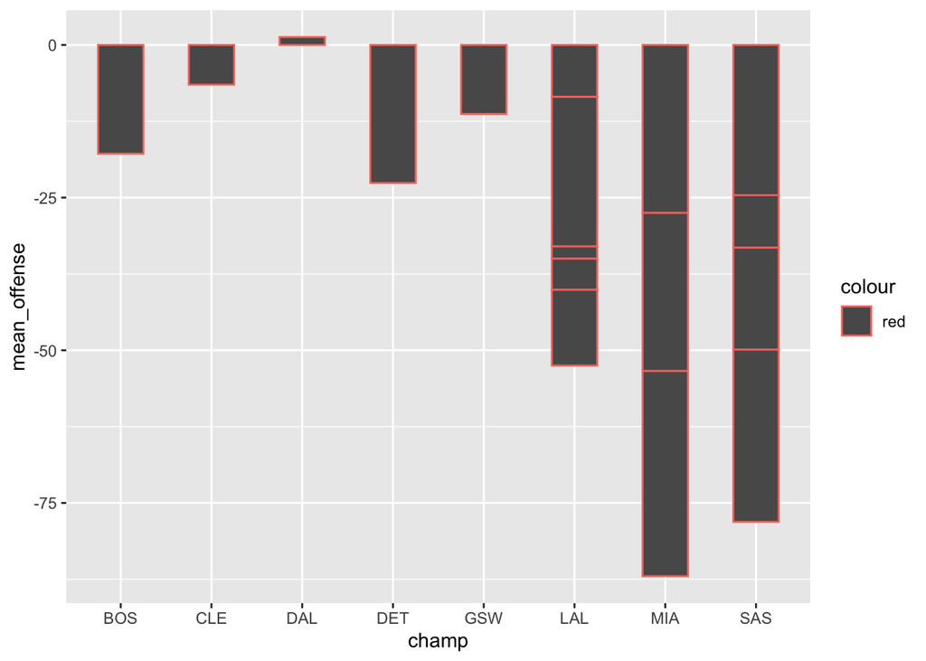

```r
offense_champs %>%
  ggplot(mapping=aes(x=champ, y=mean_offense, color="red", width=0.5)) +
    geom_bar(stat="identity")
```

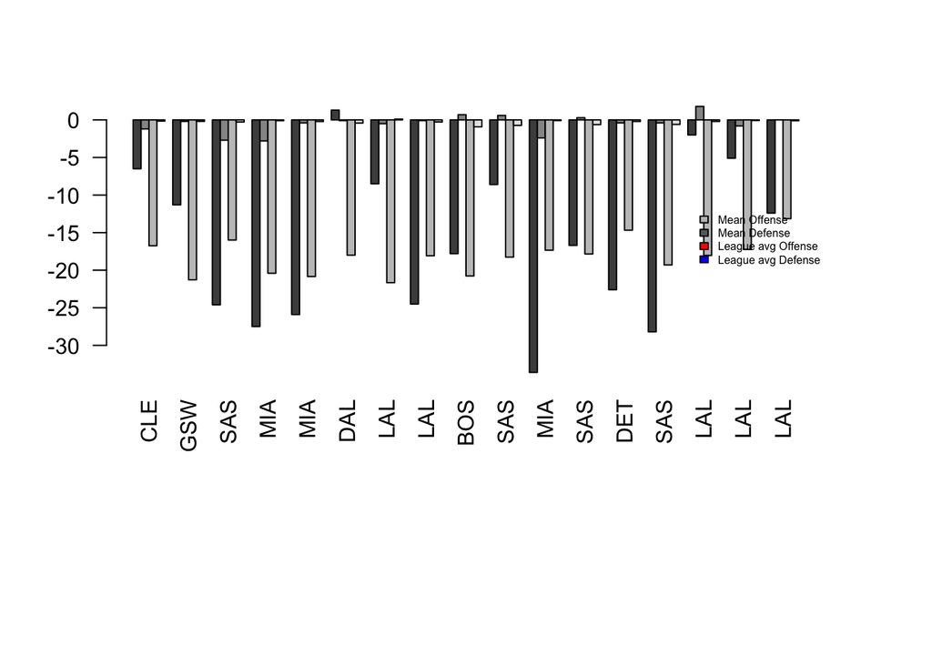

```r
par(mar=c(11,4,4,4))
test2 <- rbind(offense_champs$mean_offense,offense_champs$mean_defense, year_avg$league_avg_offense, year_avg$league_avg_defense)
barplot(test2,beside=T, names.arg = offense_champs$champ, las=2, legend = T)
legend("right",
       legend = c("Mean Offense", "Mean Defense", "League avg Offense", "League avg Defense"),
       fill = c("grey", "dimgrey", "red", "blue"),
       bty = "n",
       cex = 0.5)
```

```r
performances <- nba_performance
performances <- performances %>% select(Year, Team, `Winning Percentage`) %>% arrange(Year)
performances$Year <- substr(performances$Year, 1, 4) %>% as.numeric()
performances
```

```
## # A tibble: 506 x 3
##     Year Team  `Winning Percentage`
##    <dbl> <chr>                <dbl>
##  1  2000 BOS                  0.439
##  2  2000 ATL                  0.305
##  3  2000 BRK                  0.317
##  4  2000 CHH                  0.561
##  5  2000 CHI                  0.183
##  6  2000 CLE                  0.366
##  7  2000 DAL                  0.646
##  8  2000 DEN                  0.488
##  9  2000 DET                  0.39
## 10  2000 GSW                  0.207
## # … with 496 more rows
```

```r
payroll_df <- read_csv("NBA_Season_Data.csv")
payroll_df$TrueSalary <- as.numeric(gsub("[$,]", "", payroll_df$TrueSalary))
payroll_df <- payroll_df %>% filter(!is.na(TrueSalary))
payroll_df <- payroll_df %>% filter(Year > 2000) %>%
  group_by(Tm, Year) %>%
  mutate(payroll=sum(TrueSalary), PER_year=mean(PER)) %>%
  distinct(Year, Tm, payroll, PER_year)
payroll_df
```

```
## # A tibble: 476 x 4
## # Groups:   Tm, Year [476]
##     Year Tm      payroll PER_year
##    <dbl> <chr>     <dbl>    <dbl>
##  1  2001 DAL   102500000     14.8
##  2  2001 BOS    45800000     13.5
##  3  2001 GSW    29800000     13.7
##  4  2001 MIA    77200000     15.6
##  5  2001 SEA    64700000     15
##  6  2001 VAN    34700000     13.7
##  7  2001 DET    51100000     13.7
##  8  2001 MIN    66500000     14.9
##  9  2001 HOU    73000000     15.5
## 10  2001 CHH    67700000     14.6
## # … with 466 more rows
```

```r
classify <- function(yearID) {
  if (yearID >= 2000 && yearID <= 2004) "[2000,2004]"
  else if (yearID > 2004 && yearID <= 2009) "(2004,2009]"
  else if (yearID > 2009 && yearID <= 2013) "(2009,2013]"
  else if (yearID > 2013 && yearID <= 2016) "(2013,2016]"
}
times <- c("[2000,2004]", "(2004,2009]", "(2009,2013]", "(2013,2016]")
payroll_df <- payroll_df %>%
                      mutate(time_period = classify(Year))
payroll_df
```

```
## # A tibble: 476 x 5
## # Groups:   Tm, Year [476]
##     Year Tm      payroll PER_year time_period
##    <dbl> <chr>     <dbl>    <dbl> <chr>
##  1  2001 DAL   102500000     14.8 [2000,2004]
##  2  2001 BOS    45800000     13.5 [2000,2004]
##  3  2001 GSW    29800000     13.7 [2000,2004]
##  4  2001 MIA    77200000     15.6 [2000,2004]
##  5  2001 SEA    64700000     15   [2000,2004]
##  6  2001 VAN    34700000     13.7 [2000,2004]
##  7  2001 DET    51100000     13.7 [2000,2004]
##  8  2001 MIN    66500000     14.9 [2000,2004]
##  9  2001 HOU    73000000     15.5 [2000,2004]
## 10  2001 CHH    67700000     14.6 [2000,2004]
## # … with 466 more rows
```

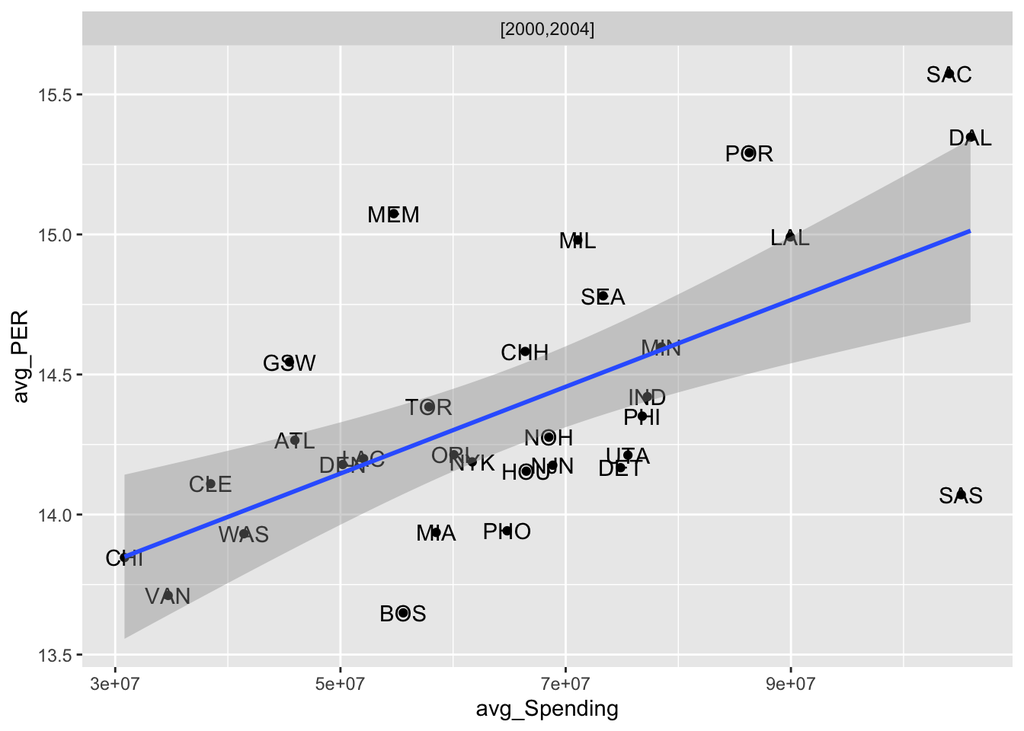

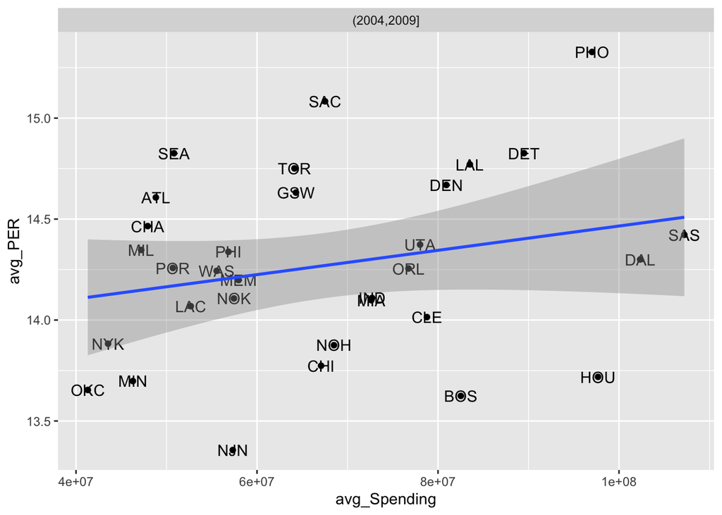

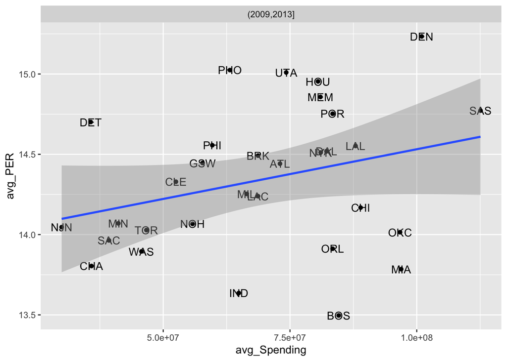

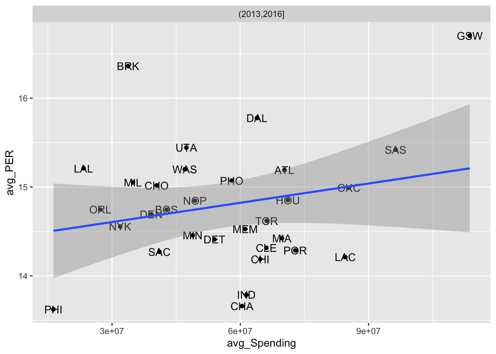

```r
winnings <- payroll_df %>% group_by(Tm, time_period) %>% mutate(avg_PER=mean(PER_year), avg_Spending=mean(payroll)) %>% distinct(Tm, avg_PER, avg_Spending)
for (t in times) {
  x <- filter(winnings, time_period == t)
  print(x %>%
      ggplot(aes(x=avg_Spending, y=avg_PER, label=Tm)) +
      facet_grid(~time_period) +
      geom_text() +
      geom_point() +
      geom_smooth(method=lm))

}
```

## Exploratory data analysis

```r
moneyball <- left_join(performances, payroll_df, by=c("Year" = "Year", "Team" = "Tm"))
moneyball <- moneyball %>% filter(!is.na(payroll))
moneyball <- rename(moneyball, win_p = "Winning Percentage")
moneyball
```

```
## # A tibble: 438 x 6
##     Year Team  win_p   payroll PER_year time_period
##    <dbl> <chr> <dbl>     <dbl>    <dbl> <chr>
##  1  2001 BOS   0.598  45800000     13.5 [2000,2004]
##  2  2001 ATL   0.402  48200000     13.9 [2000,2004]
##  3  2001 CHH   0.537  67700000     14.6 [2000,2004]
##  4  2001 CHI   0.256  27400000     15.1 [2000,2004]
##  5  2001 CLE   0.354  38900000     14.4 [2000,2004]
##  6  2001 DAL   0.695 102500000     14.8 [2000,2004]
##  7  2001 DEN   0.329  51500000     15.0 [2000,2004]
##  8  2001 DET   0.61   51100000     13.7 [2000,2004]
##  9  2001 GSW   0.256  29800000     13.7 [2000,2004]
## 10  2001 HOU   0.341  73000000     15.5 [2000,2004]
## # … with 428 more rows
```

```r
winnings <- moneyball %>% group_by(Team, time_period) %>% mutate(avg_Spending=mean(payroll), win_percentage=mean(win_p)) %>% distinct(Tm, avg_Spending, win_percentage)
winnings
```

```
## # A tibble: 113 x 4
## # Groups:   Team, time_period [113]
##    avg_Spending win_percentage Team  time_period
##           <dbl>          <dbl> <chr> <chr>
##  1     55575000          0.531 BOS   [2000,2004]
##  2     45950000          0.332 ATL   [2000,2004]
##  3     66400000          0.555 CHH   [2000,2004]
##  4     30825000          0.369 CHI   [2000,2004]
##  5     38475000          0.375 CLE   [2000,2004]
##  6    105950000          0.692 DAL   [2000,2004]
##  7     50200000          0.414 DEN   [2000,2004]
##  8     74875000          0.635 DET   [2000,2004]
##  9     45475000          0.396 GSW   [2000,2004]
## 10     66500000          0.509 HOU   [2000,2004]
## # … with 103 more rows
```

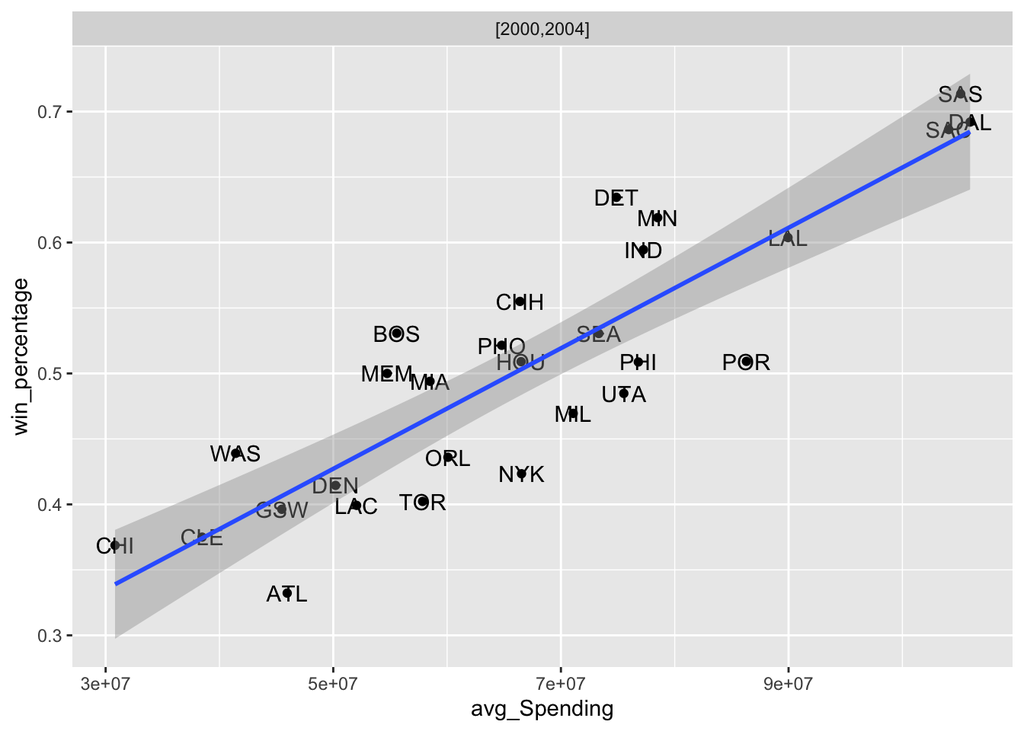

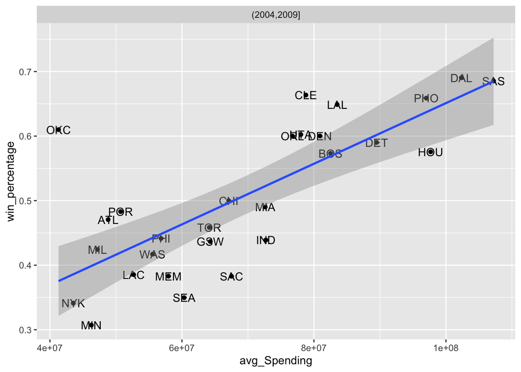

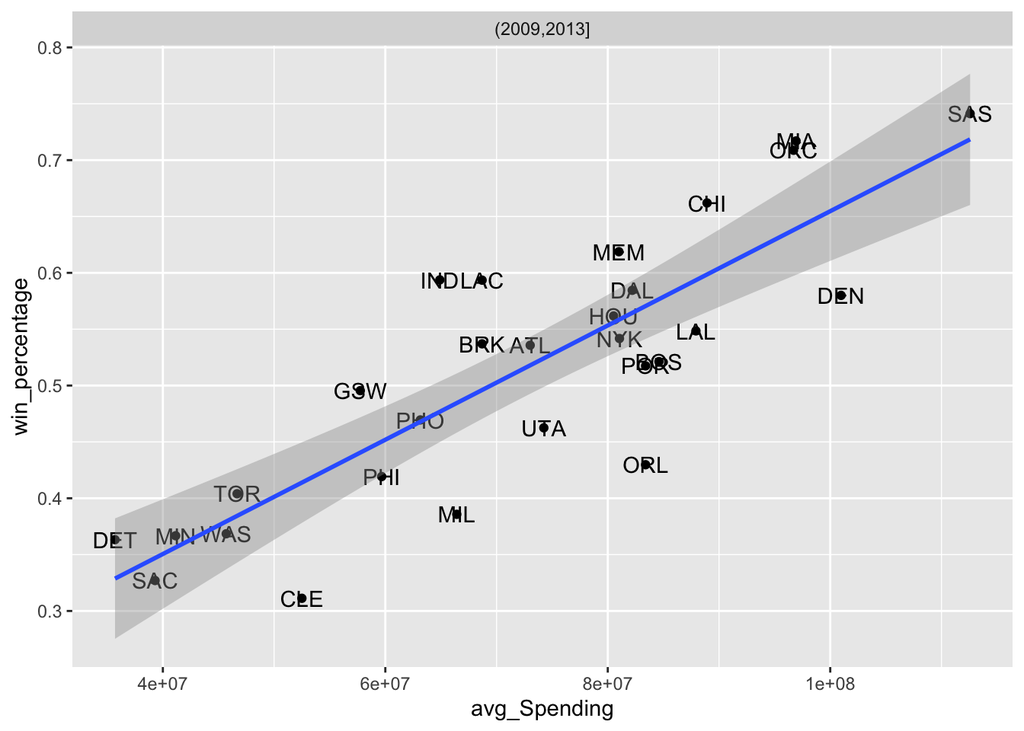

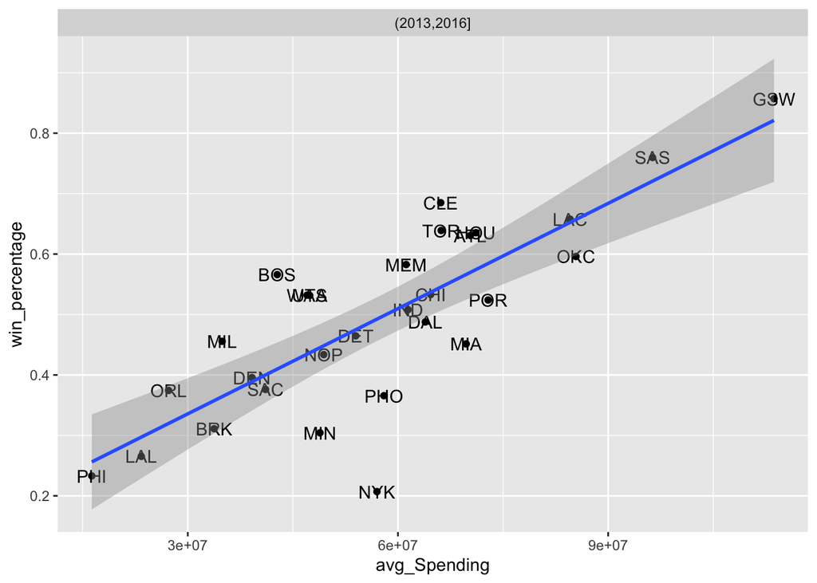

```r
for (t in times) {
  x <- filter(winnings, time_period == t)
  print(x %>%
      ggplot(aes(x=avg_Spending, y=win_percentage, label=Team)) +
      facet_grid(~time_period) +
      geom_text() +
      geom_point() +
      geom_smooth(method=lm))

}
```

```r
time_period_df <- moneyball %>%
  group_by(Team, time_period) %>%
  mutate(avg_winPct = mean(win_p), avg_payroll = mean(payroll), efficiency = avg_winPct/avg_payroll, time_pd=cut(Year,breaks=4)) %>%
  arrange(time_period)
```

[output not shown]

[output cut: 283 more lines]

[output not shown]

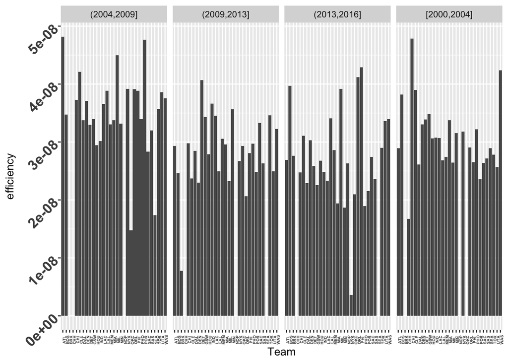

```r
time_period_df %>%
  ggplot(aes(x=Team, y=efficiency, label=Team)) +
    facet_grid(~time_period) +
    geom_bar(stat="identity") +
 theme(axis.text.x = element_text(face="bold",
                           size=4, angle=90),
          axis.text.y = element_text(face="bold",
                           size=14, angle=45))
```

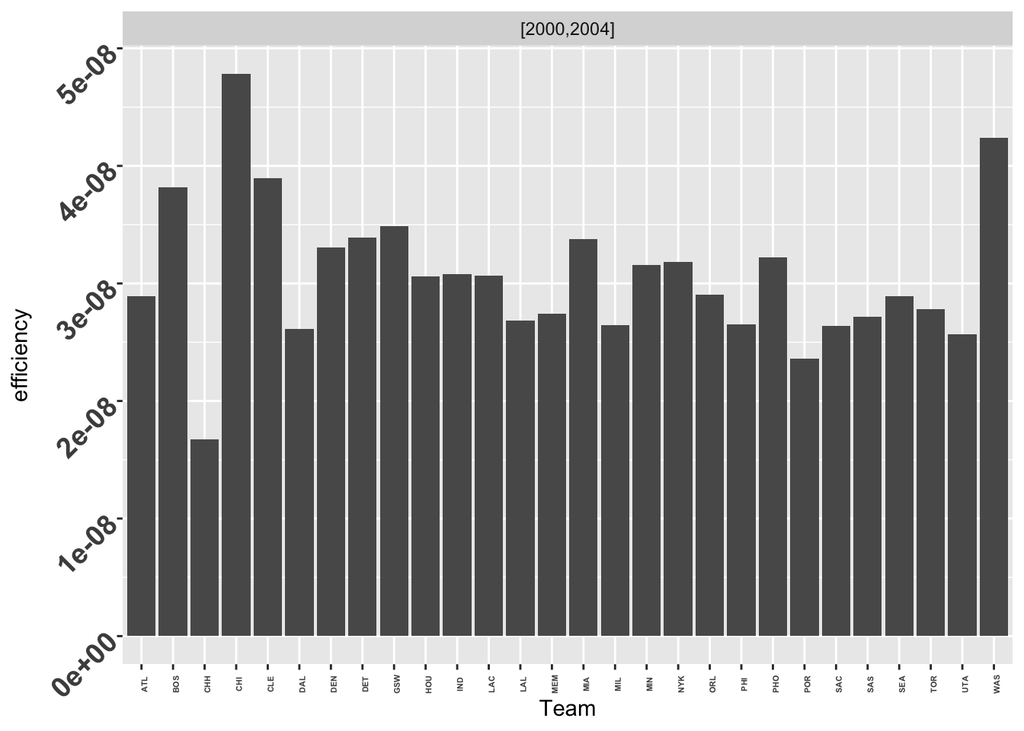

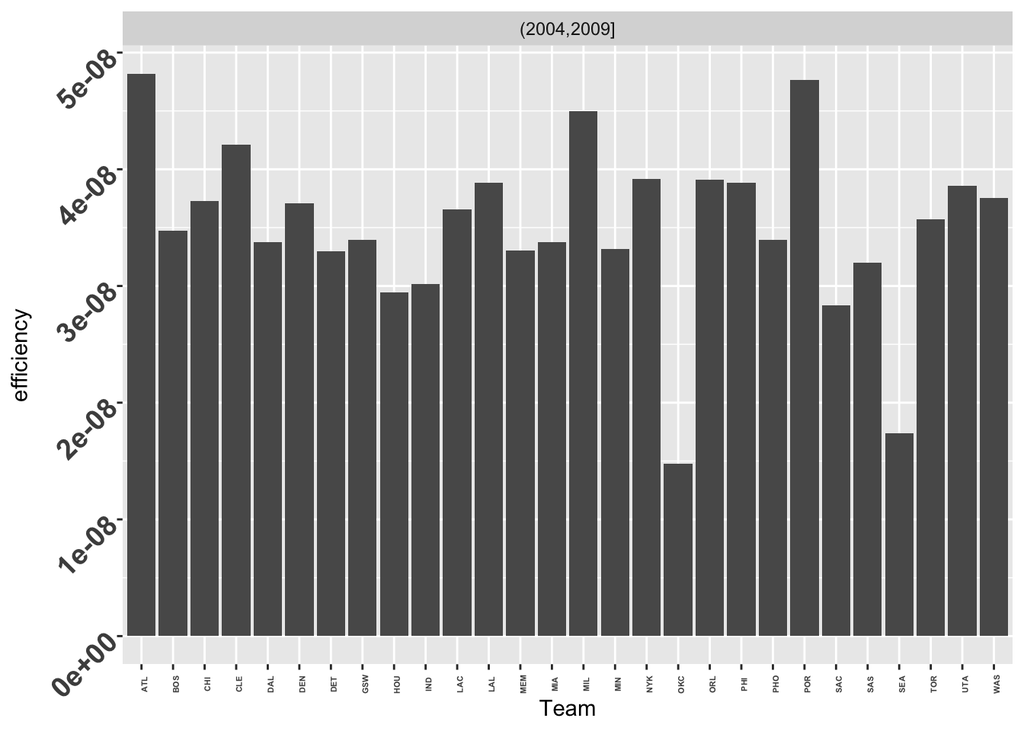

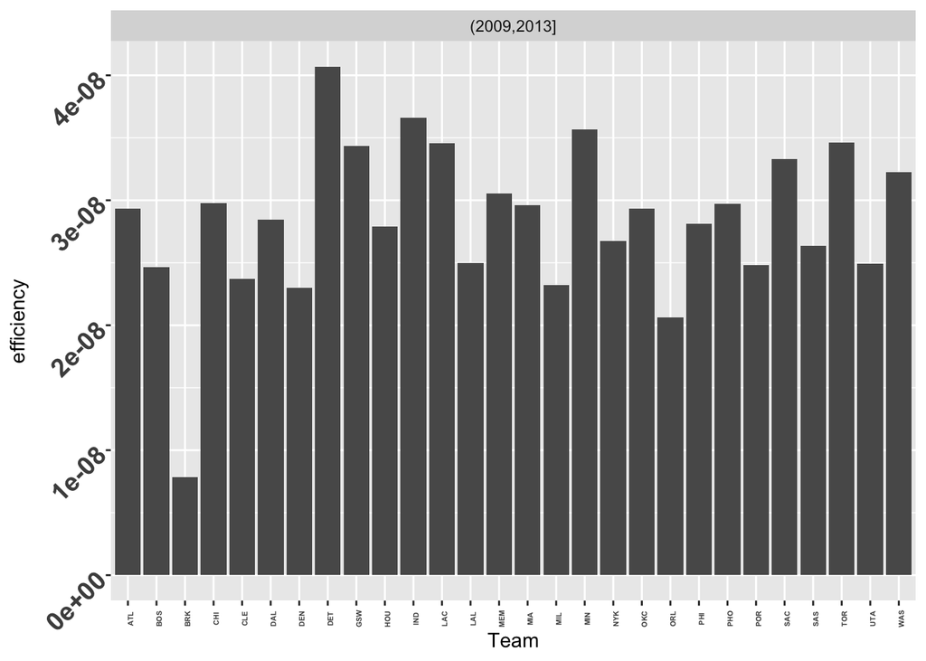

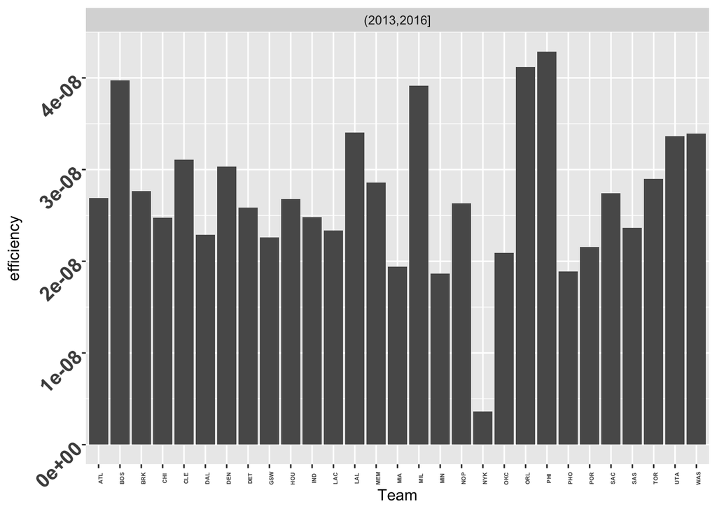

```r
for (t in times) {
  x <- filter(time_period_df, time_period == t)
  print(x %>%
          ggplot(aes(x=Team, y=efficiency, label=Team)) +
          facet_grid(~time_period) +
          geom_bar(stat="identity") +
          theme(axis.text.x = element_text(face="bold", size=4, angle=90),
          axis.text.y = element_text(face="bold", size=14, angle=45)) )
}
```

In this section we want to know and visualize the correlation between the payroll and the winning percentage in the NBA database. By doing this it will help us understando the importance of the payroll amound among the teams and compare it to the NBA Champions during five time periods.

```r
nba_data <- left_join(performances, payroll_df, by=c("Year" = "Year", "Team" = "Tm"))
nba_data <- nba_data %>% filter(!is.na(payroll))
nba_data <- rename(nba_data, win_p = "Winning Percentage")
winnings <- nba_data %>% group_by(Team, time_period) %>% mutate(avg_Spending=mean(payroll), win_percentage=mean(win_p)) %>% distinct(Tm, avg_Spending, win_percentage)
## left join
#nba_data <- sqldf("SELECT m.*, (m.Team = off.champ) as champs
#              FROM moneyball as m
#              LEFT JOIN offense_champs as off ON m.Year = off.Year")

nba_data <- left_join(moneyball, offense_champs, by=c("Year"="Year"))
nba_data
```

```
## # A tibble: 438 x 9
##     Year Team  win_p payroll PER_year time_period champ mean_offense
##    <dbl> <chr> <dbl>   <dbl>    <dbl> <chr>       <chr>        <dbl>
##  1  2001 BOS   0.598  4.58e7     13.5 [2000,2004] LAL           -5.1
##  2  2001 ATL   0.402  4.82e7     13.9 [2000,2004] LAL           -5.1
##  3  2001 CHH   0.537  6.77e7     14.6 [2000,2004] LAL           -5.1
##  4  2001 CHI   0.256  2.74e7     15.1 [2000,2004] LAL           -5.1
##  5  2001 CLE   0.354  3.89e7     14.4 [2000,2004] LAL           -5.1
##  6  2001 DAL   0.695  1.02e8     14.8 [2000,2004] LAL           -5.1
##  7  2001 DEN   0.329  5.15e7     15.0 [2000,2004] LAL           -5.1
##  8  2001 DET   0.61   5.11e7     13.7 [2000,2004] LAL           -5.1
##  9  2001 GSW   0.256  2.98e7     13.7 [2000,2004] LAL           -5.1
## 10  2001 HOU   0.341  7.30e7     15.5 [2000,2004] LAL           -5.1
## # … with 428 more rows, and 1 more variable: mean_defense <dbl>
```

```r
nba_data$is_champ <- nba_data$champ == nba_data$Team
nba_data
```

```
## # A tibble: 438 x 10
##     Year Team  win_p payroll PER_year time_period champ mean_offense
##    <dbl> <chr> <dbl>   <dbl>    <dbl> <chr>       <chr>        <dbl>
##  1  2001 BOS   0.598  4.58e7     13.5 [2000,2004] LAL           -5.1
##  2  2001 ATL   0.402  4.82e7     13.9 [2000,2004] LAL           -5.1
##  3  2001 CHH   0.537  6.77e7     14.6 [2000,2004] LAL           -5.1
##  4  2001 CHI   0.256  2.74e7     15.1 [2000,2004] LAL           -5.1
##  5  2001 CLE   0.354  3.89e7     14.4 [2000,2004] LAL           -5.1
##  6  2001 DAL   0.695  1.02e8     14.8 [2000,2004] LAL           -5.1
##  7  2001 DEN   0.329  5.15e7     15.0 [2000,2004] LAL           -5.1
##  8  2001 DET   0.61   5.11e7     13.7 [2000,2004] LAL           -5.1
##  9  2001 GSW   0.256  2.98e7     13.7 [2000,2004] LAL           -5.1
## 10  2001 HOU   0.341  7.30e7     15.5 [2000,2004] LAL           -5.1
## # … with 428 more rows, and 2 more variables: mean_defense <dbl>,
## #   is_champ <lgl>
```

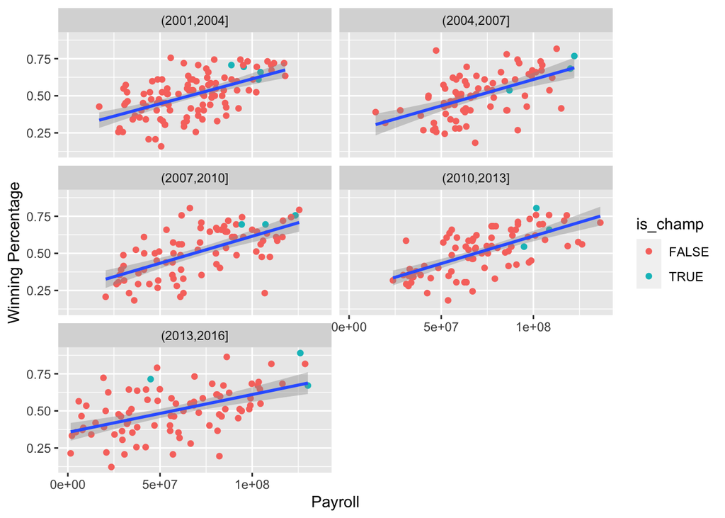

```r
gg1 <- ggplot(nba_data, aes(x=payroll, y=win_p)) +
        geom_point(aes(color= is_champ)) +
        labs(x="Payroll", y="Winning Percentage", fill= "Champtions") +
        geom_smooth(method=lm) #add regression line
gg1 + facet_wrap( ~ cut(Year, breaks =5), ncol=2)
```

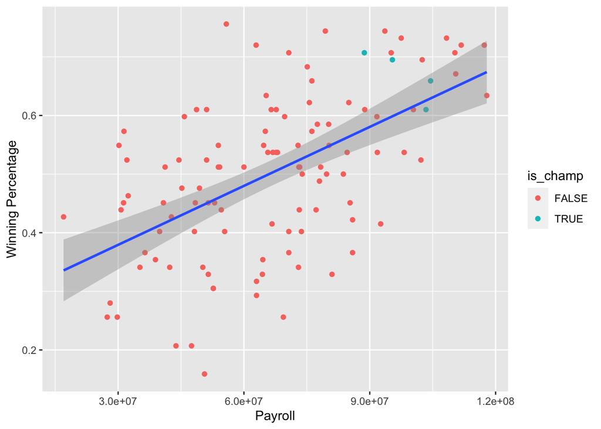

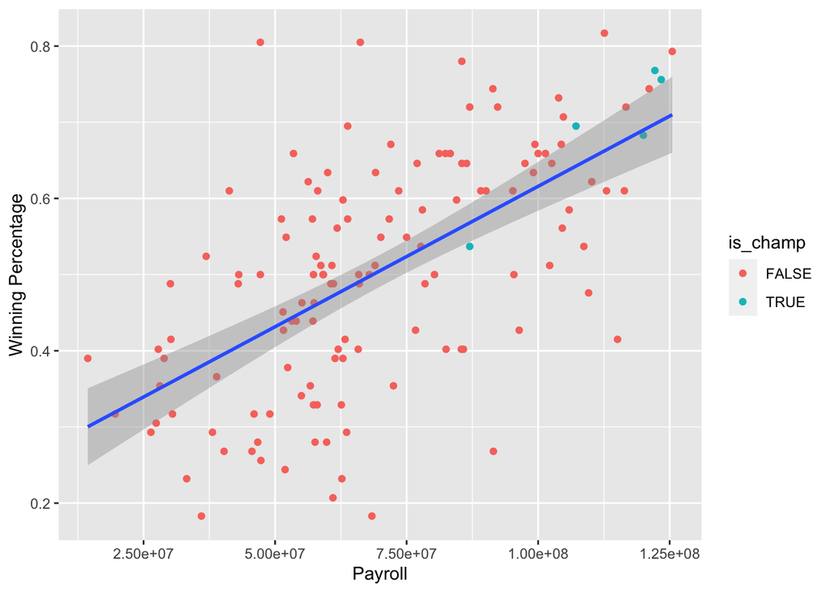

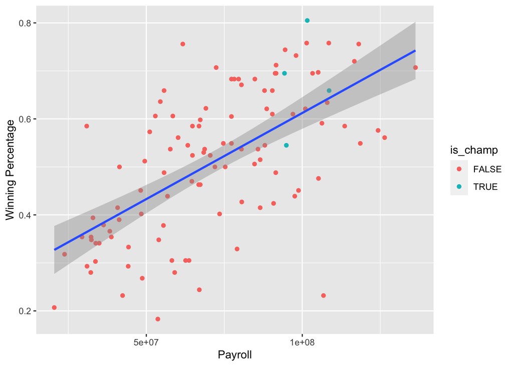

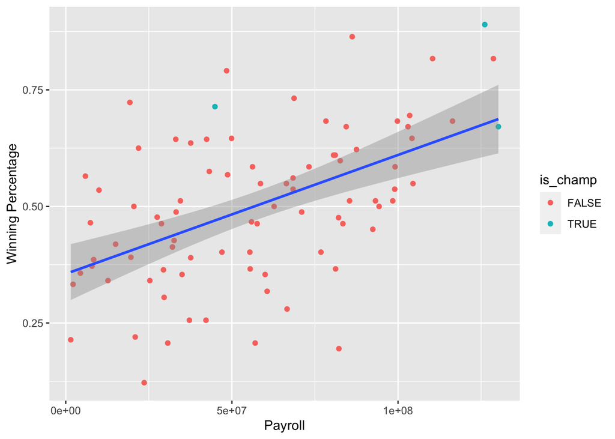

```r
for (t in times) {
  x <- filter(nba_data, time_period == t)
  gg1 <- ggplot(x, aes(x=payroll, y=win_p)) +
        geom_point(aes(color= is_champ)) +
        labs(x="Payroll", y="Winning Percentage", fill= "Champtions") +
        geom_smooth(method=lm) #add regression line
        gg1 + facet_wrap( ~ cut(Year, breaks =5), ncol=2)
  print(gg1)
}
```